# Regression Based Models

#### Backward Selection

```r
nrcore <- 5
cl <- makeCluster(mc <- getOption("cl.cores", nrcore))
registerDoParallel(cl)
set.seed(123)
leapB <- train(Salary ~., data = MyBankAccount,
               method = "leapBackward",
               trControl = rcvControl,
               preProcess = c("center","scale"),
               tuneGrid = expand.grid(nvmax = 1:12))
stopCluster(cl)
```

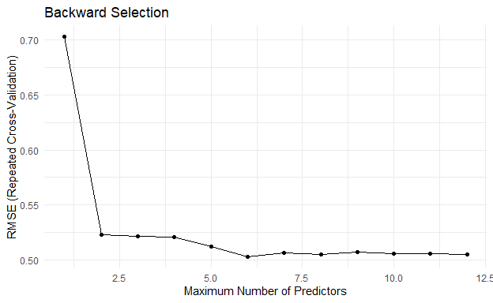

```r
ggplot(leapB)+
  ggtitle("Backward Selection") +
  theme_minimal()
```

```r
# Regression results
coef(leapB$finalModel,leapB$bestTune$nvmax)  %>%
  kable(digits=2) %>%
  kable_styling()
```

|  | x |
| --- | --- |
| (Intercept) | 5.93 |
| Gas | 0.11 |
| TotalHighTrans | 0.54 |
| TotalShopping | 0.23 |
| OnlineTrans | 0.10 |
| Years2 | -0.73 |
| Years3 | 0.27 |

#### Stepwise Selection

```r
nrcore <- 5
cl <- makeCluster(mc <- getOption("cl.cores", nrcore))
registerDoParallel(cl)
set.seed(123)
leapS <- train(Salary ~., data = MyBankAccount,
               method = "leapSeq",
               trControl = rcvControl,
               preProcess = c("center","scale"),
               tuneGrid = expand.grid(nvmax = 1:12))
stopCluster(cl)
```

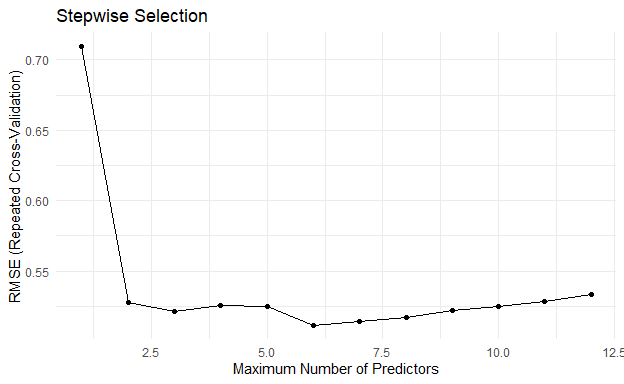

```r
ggplot(leapS)+
  ggtitle("Stepwise Selection") +
  theme_minimal()
```

```r
# Regression results
coef(leapS$finalModel,leapS$bestTune$nvmax)  %>%
  kable(digits=2) %>%
  kable_styling()
```

|  | x |
| --- | --- |
| (Intercept) | 5.93 |
| Dinning | 0.12 |
| TotalHighTrans | 0.50 |
| TotalShopping | 0.27 |
| OnlineTrans | 0.10 |
| Years2 | -0.73 |
| Years3 | 0.29 |

**Remarks**

- You can generate predictions from each model using the command *predict*.
- You can look at variable importance using *varImp*. For linear model, variable importance is proportional to the absolute value of the t statistic, something completely different from the measure we introduced above.

> Compare the different sets of variables for each method.

#### Comparison of Models

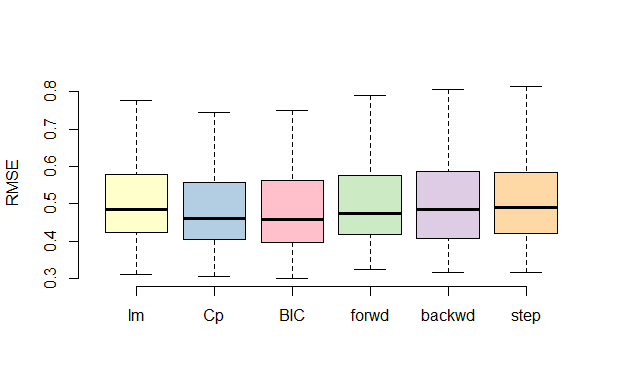

```r
models <- list(lm = lm, cp = lmcp, BIC = lmBIC,
               forward = leapF, backward = leapB,
               stepwise = leapS)
perf <- resamples(models)
colvec <- colvec <- c('#ffffcc','#b3cde3', "pink", '#ccebc5','#decbe4','#fed9a6')
boxplot(perf$values[c("lm~RMSE", "cp~RMSE", "BIC~RMSE",
                      "forward~RMSE", "backward~RMSE",
                      "stepwise~RMSE")],
        #names = names(models),
        names = c("lm", "Cp", "BIC", "forwd", "backwd", "step"),
        col=colvec,
         ylab="RMSE",
        frame.plot = FALSE)
```

#### The Trouble with CV Selection

One characteristic of CV stepwise selection is that for each K-fold, we may end up with a different subset of regressors, even if the “optimal” number of regressors is the same. Hence once one has chosen the number of regressors, it still remains to choose which set of regressors.

(It seems that) Caret uses a majority rule to select regressors and uses an extra K-fold CV to break up ties.

# Penalization Methods

Penalization methods can prevent the common problem of model complexity. When we have a model with many explanatory variables they tend to have large variances, especially so if there is correlation in the data. This will affect the reliability of the fitted model. If you recall the **bias and variance** tradeoff, we use **penalization** techniques to intentionally introduce **bias** in our model with the result of lowering the **variance**.

## Ridge Regression

Ridge regression is typically used when there is almost multicollinearity among regressors. It also applies when $p \geq n$!  
It is defined as the solution of the *penalized least-squares problem*

$$\min_{\beta} \frac{1}{2n}
\sum_{i=1}^{n}{ \left( y_i - \beta_0 - x'_i\beta\right)^{2} } +
\lambda \frac{\| \beta\|^{2}}{2}
\, .$$
The ridge regression problem can be rewritten as
$$\min_{\beta} \frac{1}{2n}
\sum_{i=1}^{n}{ \left( y_i - \beta_0 - x'_i\beta\right)^{2} }
\qquad \rm{such \ \ that } \quad
\| \beta\| ^{2} \leq c
\, .$$
Hence $\lambda$ is the cost of the constraint.

Ridge regression shrinks parameters towards zero and thus avoids too large parameters. It introduces some bias in estimation in order to reduce variance. We need to center and scale each of the $x$: hence components of $\beta$ is relatively small (typically less than one) and comparabe. The solution is the ridge estimator
$$\widehat{\beta} = \left( \frac{X'X}{n} + \lambda \, I \right)^{-1}
\frac{X' y}{n}$$
If we have almost multicollinearity, $X'X$ cannot be inverted, or is difficult to invert numerically because some eigenvalues are close to zero. When $\lambda > 0$, the matrix $X'X + \lambda I$ is invertible. This works even for $p \geq n$, where $X'X$ cannot be inverted!

Now $\lambda$ becomes the parameter that we should choose by some validation method. It is between 0 and 1, typically small, and we usually select it on the log scale.

> Why is it important to center and scale variables before performing LASSO and Ridge regularization?

Scaling ensures that that the coefficient of the regression are comparable. This ensures that the penalty term penalizes each coefficient equally, independently of the units of the corresponding variable.

```r
# Control variables
numbers <- 5
repeats <- 20
rcvTunes <- 10 # tune number of models
seed <- 123
# repeated cross validation
rcvSeeds <- setSeeds(method = "repeatedcv",
                     numbers = numbers, repeats = repeats,
                     tunes = rcvTunes, seed = seed)


# Controls for the CV
rcvControl <- trainControl(method = "repeatedcv",
                        number = numbers, repeats = repeats,
                        seeds = rcvSeeds)

# Parallel computing initialization
nrcore <- 5
cl <- makeCluster(mc <- getOption("cl.cores", nrcore))
registerDoParallel(cl)

set.seed(123)
lambda <- 10^(-seq(1.8, 0.9, length = rcvTunes))
set.seed(123)
ridge <- train(Salary ~., data = MyBankAccount,
               method = "glmnet",
               trControl = rcvControl,
               preProcess = c("center","scale"),
               tuneGrid = expand.grid(alpha = 0,
                                      lambda = lambda))
stopCluster(cl)
```

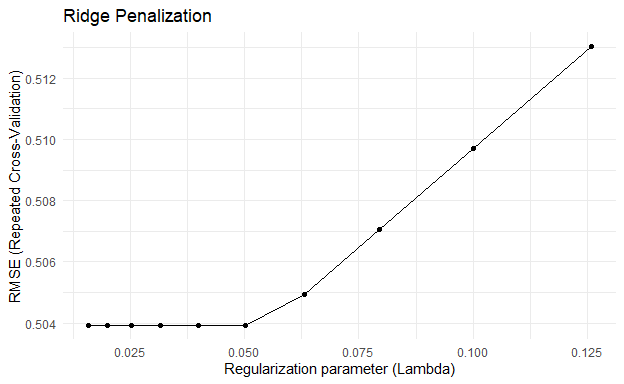

```r
ggplot(ridge) +
  ggtitle("Ridge Penalization") +
  labs(x = "Regularization parameter (Lambda)")+
  theme_minimal()
```

```r
cbind( ridge$bestTune$lambda,
          -log(ridge$bestTune$lambda)/log(10)) %>%
  kable(digits=3, col.names = c("lambda (exp)", "lambda (true)")) %>%
  kable_styling()
```

| lambda (exp) | lambda (true) |
| --- | --- |
| 0.05 | 1.3 |

**Note** The method select lambda, and the model is estimated with the optimal lambda using the whole dataset.

```r
# All the models are in ridge$finalModel
# We present the one corresponding to the optimal lambda
coef(ridge$finalModel,ridge$bestTune$lambda)
```

```
## 22 x 1 sparse Matrix of class "dgCMatrix"
##                          s1
## (Intercept)     5.927221541
## Trans          -0.068580111
## HighTrans       0.115324115
## Checks          0.035504735
## Dinning         0.060233770
## Shopping        0.005110423
## Gas             0.050249766
## Years           0.125580877
## TotalTrans      0.127354843
## TotalHighTrans  0.204769088
## TotalChecks     0.016688464
## TotalDinning    0.147551862
## TotalShopping   0.112632675
## TotalGas        0.016065266
## CategoryN       0.080746186
## AgencyW        -0.041525629
## OnlineTrans     0.094942900
## widthdrawals    0.015016187
## RejectedTrans  -0.029376835
## NewCategory    -0.038484496
## Years2         -0.518164945
## Years3          0.108369743
```

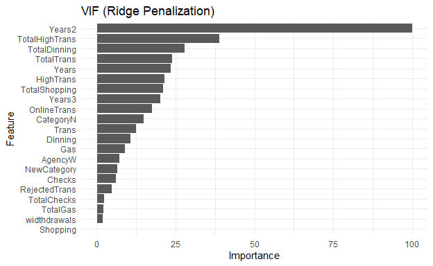

```r
ggplot(varImp(ridge))+
  ggtitle("VIF (Ridge Penalization)") +
  theme_minimal()
```

## Least Absolute Shrinkage and Selection Operator (LASSO)

A very common form of regularization in machine learning is **LASSO**. It is commonly referred to as **L1 regularization**. The **LASSO** regularization shrinks unnecessary parameters estimates to 0 to simplify the model: Lasso is defined as the solution of the penalized least-squares problem
$$\min_{\beta} \frac{1}{2n}
\sum_{i=1}^{n}{ \left( y_i - \beta_0 - x'_i\beta\right)^{2} } +
\lambda |\beta|
\qquad
|\beta| = \sum_{j=1}^k |\beta_j| \, .$$
The lasso problem can be rewritten as
$$\min_{\beta} \frac{1}{2n}
\sum_{i=1}^{n}{ \left( y_i - \beta_0 - x'_i\beta\right)^{2} }
\qquad \rm{such \ \ that } \quad
|\beta| \leq c
\, .$$
Hence $\lambda$ is the cost of the constraint.

- If $\lambda = 0$, we obtain OLS. If $\lambda = \infty$, all parameters are zero.
- Lasso regression shrinks parameters towards zero more than ridge does.
- It can be shown that if $\lambda$ is large enough, the solution put some parameters to zero: Lasso does automatic *variable selection*.
- One should *center* and *scale* each component of $x$.
- $\lambda$ becomes the parameter to choose.

```r
nrcore <- 5
cl <- makeCluster(mc <- getOption("cl.cores", nrcore))
registerDoParallel(cl)

lambda <- 10^(-seq(2.5, 1.6, length = rcvTunes))

set.seed(123)
lasso <- train(Salary ~., data = MyBankAccount,
               method = "glmnet",
               trControl = rcvControl,
               preProcess = c("center","scale"),
               tuneGrid = expand.grid(alpha = 1,
                                      lambda = lambda))
stopCluster(cl)
```

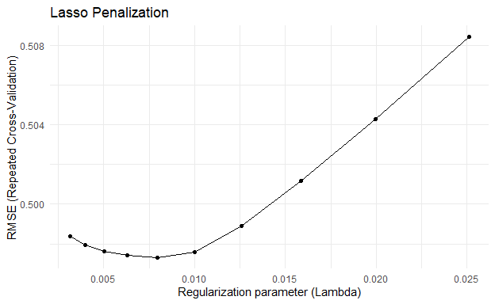

```r
ggplot(lasso)   +
  ggtitle("Lasso Penalization") +
  labs(x = "Regularization parameter (Lambda)")+
  theme_minimal()
```

```r
cbind(lasso$bestTune$lambda,
        -log(lasso$bestTune$lambda)/log(10))  %>%
  kable(digits=3, col.names = c("lambda (exp)", "lambda (true)")) %>%
  kable_styling()
```

| lambda (exp) | lambda (true) |
| --- | --- |
| 0.008 | 2.1 |

```r
coef(lasso$finalModel,lasso$bestTune$lambda)
```

```
## 22 x 1 sparse Matrix of class "dgCMatrix"
##                          s1
## (Intercept)     5.927221541
## Trans           .
## HighTrans       0.014394289
## Checks          0.038720144
## Dinning         0.064808784
## Shopping        .
## Gas             0.052935966
## Years           0.072458834
## TotalTrans      .
## TotalHighTrans  0.470087223
## TotalChecks     .
## TotalDinning    0.061487667
## TotalShopping   0.152711227
## TotalGas        .
## CategoryN       0.043014619
## AgencyW        -0.035900896
## OnlineTrans     0.087259954
## widthdrawals    .
## RejectedTrans  -0.013579879
## NewCategory    -0.008272768
## Years2         -0.635012972
## Years3          0.198500206
```

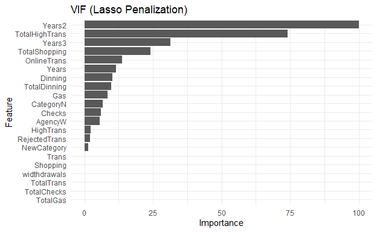

```r
ggplot(varImp(lasso)) +
  ggtitle("VIF (Lasso Penalization)") +
  theme_minimal()
```

> What is the difference between how a model is regularized when using LASSO compared to Ridge? When do you want to use which form of regularization?

**Ridge** regularization shrinks estimated coefficients towards 0. This can be useful when most parameters in the model have an impact on the target variable.

**Lasso** shrinks less important features to 0, which will end up being a way of performing *variable selection*. The **LASSO** approach is useful when only a handful of the variables are actually important in the fitted model.

## Elastic Net

It is defined as the solution of the penalized least-squares problem
$$\min_{\beta} \frac{1}{2n}
\sum_{i=1}^{n}{ \left( y_i - \beta_0 - x'_i\beta\right)^{2} } +
\lambda \left( (1-\alpha) \frac{ \|\beta\|^2}{2} + \alpha |\beta|
\right)
\, .$$

- Where $\lambda$ and $\alpha$ are two *hyper parameters* to determine through Cross Validation: .

*Elastic Net* combines, through $\alpha$, feature elimination from Lasso and feature coefficient reduction from the Ridge model to improve model predictions. If $\alpha=1$ we have the Lasso estimator, if $\alpha=0$, the Ridge regression.

```r
# control variables
rcvTunes <- 110 # tune number of models
seed <- 123
# repeated cross validation
rcvSeeds <- setSeeds(method = "repeatedcv",
                     numbers = numbers, repeats = repeats,
                     tunes = rcvTunes, seed = seed)

# Train control
rcvControl <- trainControl(method = "repeatedcv",
                        number = numbers, repeats = repeats,
                        seeds = rcvSeeds)


nrcore <- 5
cl <- makeCluster(mc <- getOption("cl.cores", nrcore))
registerDoParallel(cl)

alpha <- seq(0,1, length=11)
lambda <- round(10^(-seq(2.5, 1.6, length = 10)), 4)

set.seed(123)
enet <- train(Salary ~., data = MyBankAccount,
               method = "glmnet",
               trControl = rcvControl,
               preProcess = c("center","scale"),
               tuneGrid = expand.grid(alpha = alpha,
                                      lambda = lambda))
stopCluster(cl)
```

Since we have 2 parameter, the search is a little bit more complex and is done on a 2D grid. We restrict our grid search to a few values for $\lambda$ ( 10 values $\in$ [0.0032 , 0.0251] ) and $\alpha$ (11 values $\in$ [0 , 1] ).

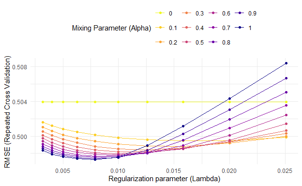

```r
# capturing the results in a dataframe
enet.res <- as.data.frame(cbind(lambda=enet$result$lambda, RMSE= enet$result$RMSE, alpha= enet$result$alpha ))
enet.res$alpha <- as.factor(enet.res$alpha)

# Plotting the results
ggplot(enet.res) +
 aes(x = lambda, y = RMSE, colour = alpha, group = alpha) +
 geom_line(size = 0.6) +
  geom_point()+
 labs(x = "Regularization parameter (Lambda)",
      y = "RMSE (Repeated Cross Validation) ",
      color = "Mixing Parameter (Alpha)")+
 scale_color_viridis_d(option = "plasma", direction = -1) +
 theme_minimal() +
 theme(legend.position = "top")
```

```r
param.enet <- cbind( enet$bestTune$alpha,
          enet$bestTune$lambda,
          -log(enet$bestTune$lambda)/log(10))

# param.enet %>%
#   kable(digits=4, col.names = c("alpha", "lambda (exp)", "lambda (true)")) %>%
#   kable_styling()
```

> The elastic net *encompass* both Ridge and Lasso estimators, at a cost of a more intensive search procedure with a 2D grid

```r
coef(enet$finalModel,enet$bestTune$lambda)
```

```
## 22 x 1 sparse Matrix of class "dgCMatrix"
##                          s1
## (Intercept)     5.927221541
## Trans           .
## HighTrans       0.014400896
## Checks          0.038735535
## Dinning         0.064841491
## Shopping        .
## Gas             0.052949120
## Years           0.072407651
## TotalTrans      .
## TotalHighTrans  0.470258331
## TotalChecks     .
## TotalDinning    0.061265583
## TotalShopping   0.152783822
## TotalGas        .
## CategoryN       0.043377004
## AgencyW        -0.035934021
## OnlineTrans     0.087277852
## widthdrawals    .
## RejectedTrans  -0.013645981
## NewCategory    -0.008622719
## Years2         -0.635296813
## Years3          0.198807308
```

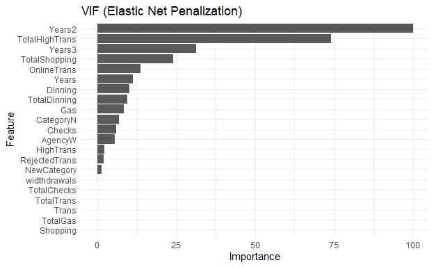

```r
ggplot(varImp(enet)) +
  ggtitle("VIF (Elastic Net Penalization)") +
  theme_minimal()
```

## Comparison of Models

It is now time to compare the models and to select the best one, in terms of lowest RMSE, for all Cross Validated samples.

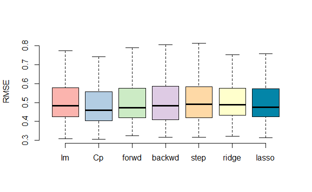

```r
models <- list( lm = lm, cp = lmcp, forward = leapF,
                backward = leapB, stepwise = leapS,
                ridge = ridge, lasso = lasso)
perf <- resamples(models)
colvec <- c('#fbb4ae','#b3cde3','#ccebc5','#decbe4','#fed9a6','#ffffcc', SIAP.color)
boxplot(perf$values[c("lm~RMSE", "cp~RMSE",
                      "forward~RMSE", "backward~RMSE",
                      "stepwise~RMSE", "ridge~RMSE", "lasso~RMSE")],
        #names = names(models),
        names = c("lm", "Cp", "forwd", "backwd", "step", "ridge", "lasso"),
        col=colvec,horizontal = FALSE,
        ylab="RMSE",
        frame.plot = FALSE)
```

# Wrap-up

- In linear regression, scaling allows to compare coefficients and to measure variable importance.
- Multicollinearity should be investigated beforehand.
- Mallows $C_p$ is a simple method to select regressors
- Stepwise methods with CV have **two** drawbacks:
  - they do not necessarily select the “best” model and
  - the choice of variables can be sensitive to the number of repetitions.
- Variable selection/elimination is done variable by variable (no interactions)
- Penalized least-squares methods can be used with multicollinearity or with a large number of regressors.
- Preliminary analysis should help decide whether we want to transform some of the regressors, e.g. to account for nonlinearities.

# Corresponding functions if you use Python

- *pandas* and *numpy* both offer great functions for handling your data.
- The package *sklearn* has functions to both fit the model both with and without penalization using *sklearn.linear_model* with functions like:
  - *linear_model.LinearRegression()*,
  - *linear_model.Ridge()*,
  - *linear_model.Lasso()* and
  - *linear_model.ElasticNet()*.

Another alternative to this is *statsmodels*, which has an *OLS()* function that provides a lot of information and evaluation criterions like AIC, BIC etc. when you use the summary function on the fitted model. However, to the best of our knowledge there is no big library for automatic variable selection in Python. - *Sklearn* also has a model_selection library which provides function for computing cross validated metrics, using the function *cross_val_score()* - *matplotlib* has good visualizations for your data and feature importance.

[^1]: *This document uses teaching materials developped by Pascal Lavergne* (*Toulouse School of Economics*)
[^2]: Remember the Residual Sum of Squares is:
    $$RSS= \sum_{i=1}^n (y_i - \widehat{f}(x_i))^2$$
    .
[^3]: Efroymson,M. A. (1960) “Multiple regression analysis,” Mathematical Methods for Digital Computers, Ralston A. and Wilf,H. S., (eds.), Wiley, New York.
[^4]: Mallows, C. L. (1973). “Some Comments on CP”. Technometrics. 15 (4): 661–675. doi:10.2307/1267380